# 🌲 LiDAR Raster Viewer

Cal Poly Arboretum — compare DSM, DTM, and CHM outputs from ArcGIS Pro and R. Toggle and blend layers to explore differences, then scroll down to the Methods section to understand why they differ.

Digital Surface Model

DSM Comparison

The DSM captures the elevation of the highest surface — tree canopy, buildings, and structures. Toggle and blend layers to compare pipelines.

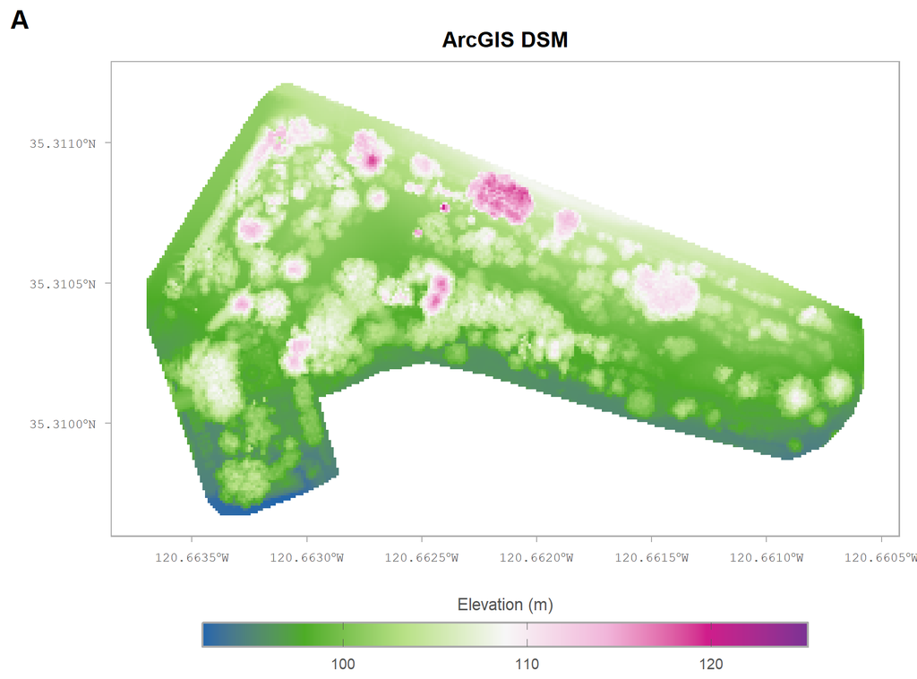

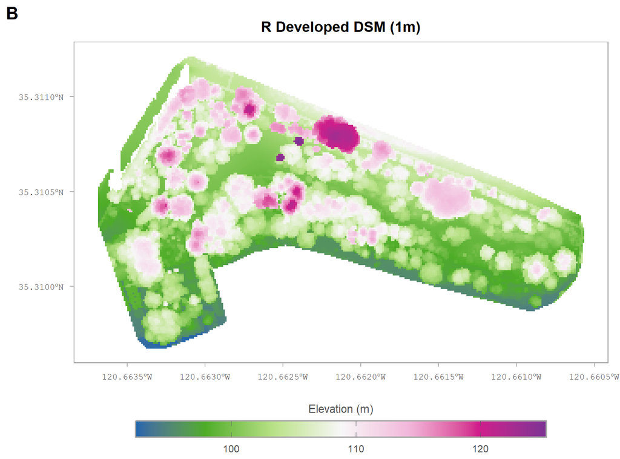

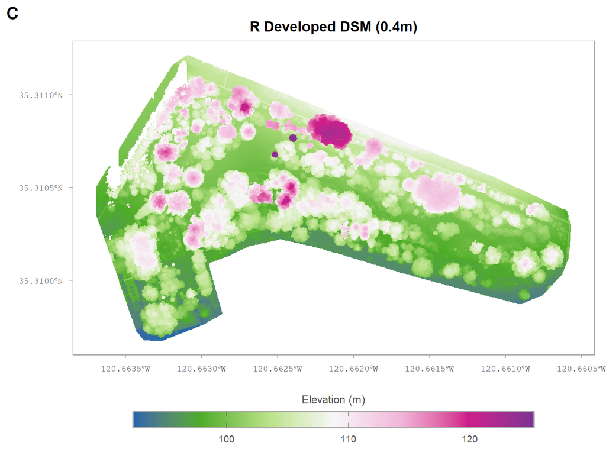

ArcGIS DSM

Visible

Opacity 100%

R DSM (1m)

Visible

Opacity 100%

R DSM (0.4m)

Visible

Opacity 100%

Digital Terrain Model

DTM Comparison

The DTM represents bare-earth elevation with vegetation and structures removed. Differences reflect how each pipeline filters ground returns.

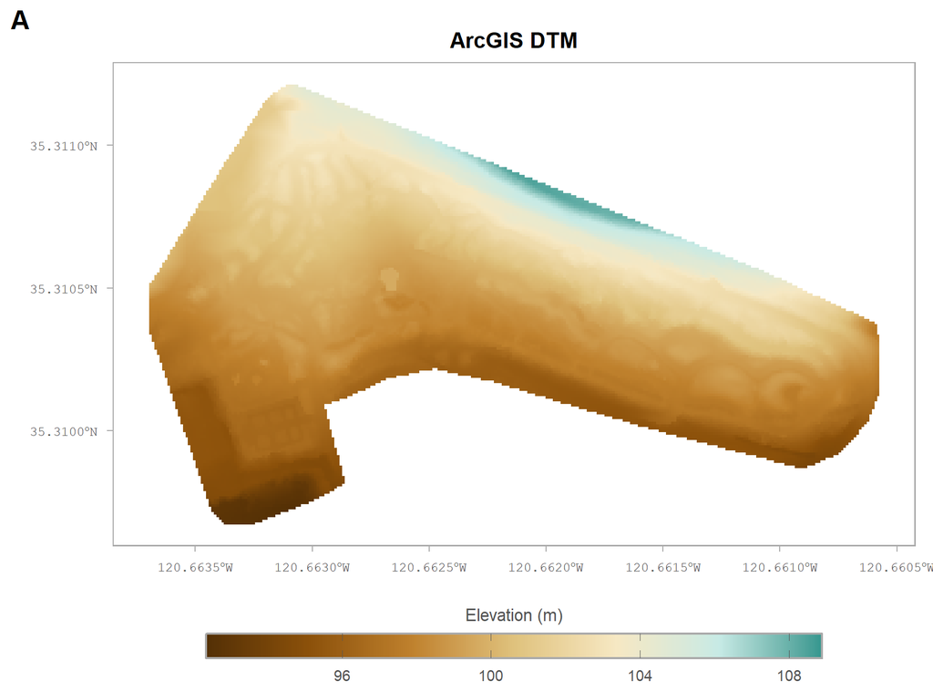

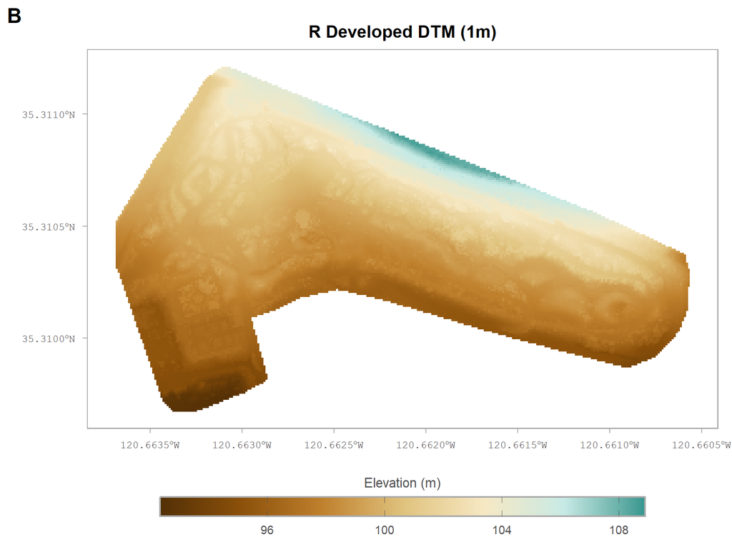

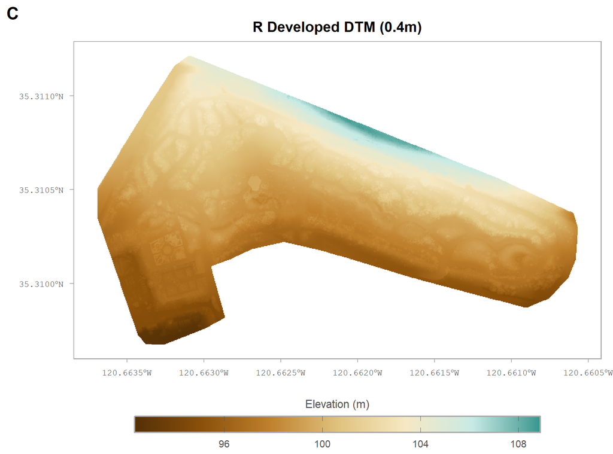

ArcGIS DTM

Visible

Opacity 100%

R DTM (1m)

Visible

Opacity 100%

R DTM (0.4m)

Visible

Opacity 100%

Canopy Height Model

CHM Comparison

The CHM is DSM minus DTM — vegetation height above ground. Toggle and blend layers to compare the three pipelines.

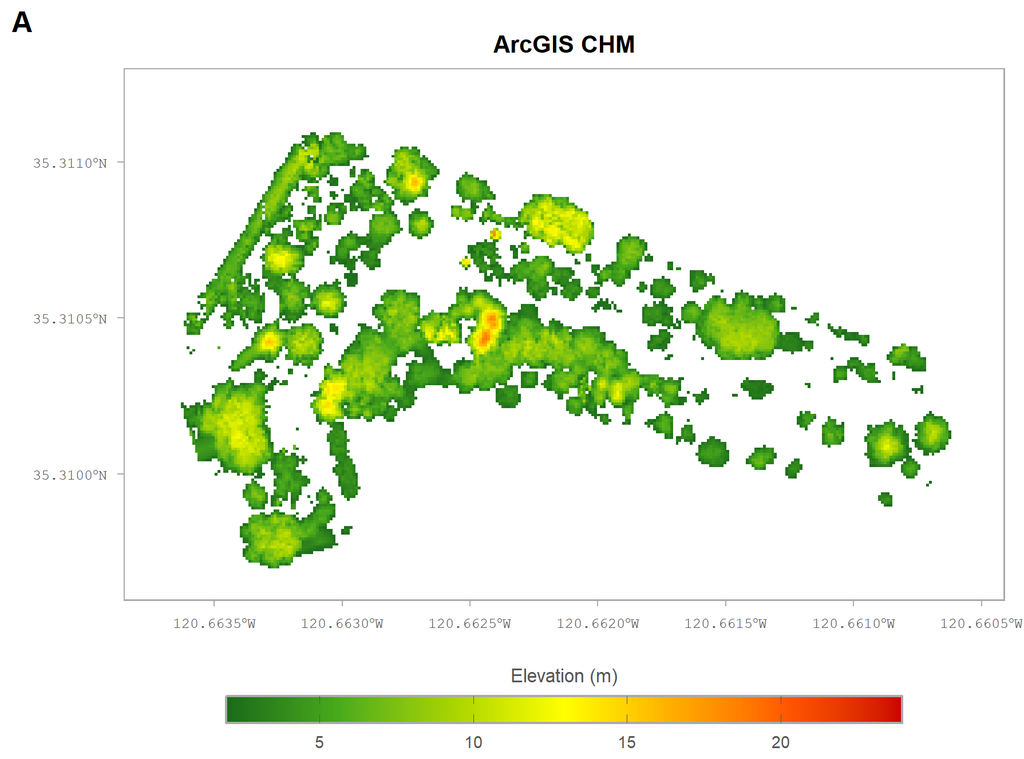

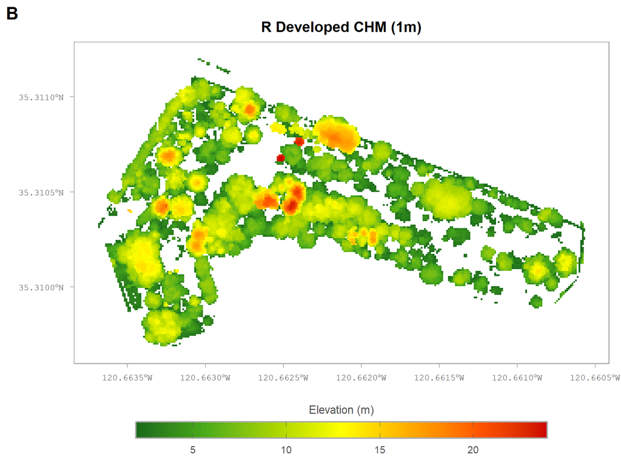

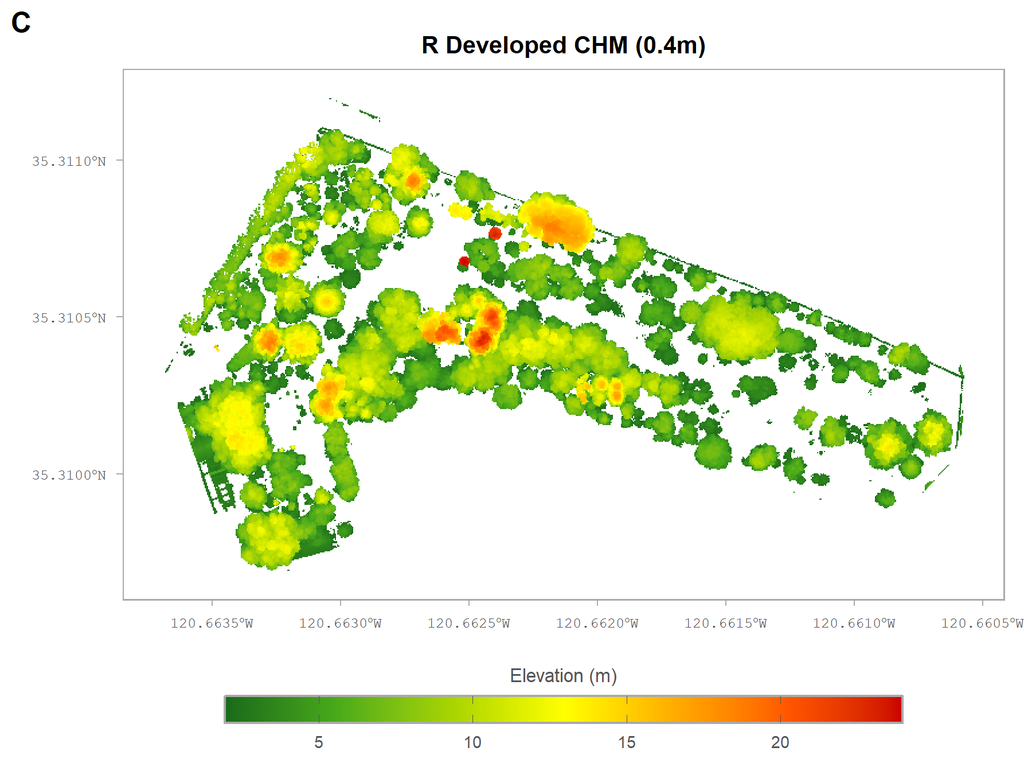

ArcGIS CHM

Visible

Opacity 100%

R CHM (1m)

Visible

Opacity 100%

R CHM (0.4m)

Visible

Opacity 100%

Methodology

Why do the ArcGIS and R outputs look different?

The two pipelines differ at every stage — from how they decide which points are "ground" to how they interpolate a continuous surface. These differences compound, producing noticeably different DSMs, DTMs, and CHMs even from the same raw LiDAR point cloud.

01

Ground classification

ArcGIS Pro

Uses the **Progressive Morphological Filter** with a "Conservative" setting and a fixed 10 m DEM resolution. The algorithm progressively opens the point cloud using a series of morphological windows, keeping only the lowest points in each window as ground candidates. The conservative mode errs toward classifying points as *non-ground* to avoid falsely including canopy as terrain.

R (lidR + RCSF)

Uses the **Cloth Simulation Filter (CSF)** (Zhang et al. 2016). Imagine draping a cloth over an upside-down version of the point cloud and letting it fall under gravity — points close to where the cloth settles are labelled ground. Parameters used: cloth resolution 0.5 m, class threshold 0.5 m, rigidness 2 (medium flexibility), 500 iterations.

Impact on outputs CSF tends to follow terrain more tightly at fine scales, while ArcGIS's conservative PMF may include fewer borderline points as ground. This directly determines what elevation values go into the DTM — and since CHM = DSM − DTM, errors here propagate into canopy height estimates.

02

DTM interpolation

ArcGIS Pro

Uses **LAS Dataset to Raster** filtered to Class 2 (ground) points. The default interpolation is binning (mean or nearest-neighbour), which averages the elevations of all ground points falling in each output cell. This produces a smoother surface but may not honour individual point positions exactly.

R (lidR)

Uses **Delaunay Triangulation (TIN)** via `rasterize_terrain(algorithm = tin())`. Ground points are connected into a mesh of non-overlapping triangles. Triangle size adapts to local point density. Each raster cell is assigned elevation by interpolating within the triangle that contains its centre — this honours every ground point exactly without smoothing.

Impact on outputs TIN interpolation produces sharper terrain features and more faithfully represents micro-topography. ArcGIS binning produces a smoother DTM. In flatter areas like the arboretum, the difference is subtle but visible at the boundary edges and in the slight elevation gradients across the site.

03

DSM construction

ArcGIS Pro

Uses **all returns or first returns** via LAS Dataset to Raster with the maximum elevation value per cell. This captures the highest surface hit by any pulse in each cell, including multi-return pulses that may have partially penetrated the canopy.

04

CHM derivation

ArcGIS Pro

CHM = DSM − DTM using **Raster Calculator**. Both inputs are in absolute elevation (metres above sea level), so the subtraction removes terrain and yields height above ground. Output cell size matches both input rasters (1 m).

Impact on outputs The ArcGIS CHM tends to show smoother, lower canopy height estimates because the conservative ground classification retains fewer ground points (raising the DTM slightly) and the binning interpolation smooths fine detail. The R CHM shows sharper, slightly taller canopy peaks because CSF classifies more points as ground (lowering the DTM) and TIN interpolation preserves height variation at fine scales.

Summary table

[output not shown]